# Relative abundance visualization in R

This tutorial will show you how to process output data from the multiple sample comparison table from **nanoARG**

The goal of this tutorial is to show you how to:

- Load relative abundances table into R
- Filter samples of interest
- Filter categories of interest (MGEs, MRGs, ARGs, etc)
- Make barplots using relative abundance (counts/Gbp)

## Required libraries in R

Please make sure to have installed these libraries in your machine

```r
require(data.table)
require(plotrix)
require(ggplot2)
require(colorspace)
options(repr.plot.width=8, repr.plot.height=5)
```

### Load data

Here we are loading the relative_abundances.tsv file downloaded from nanoARG into our environment.

```r
x = data.table(read.table('relative_abundances.tsv', sep='\t', header=TRUE, quote=NULL))
```

### Relative abundances table format

below is the format of the table downloaded from nanoARG

```r
idata = x[x$Sample == 'HFS', ]
head(idata)
```

| Sample | Section | Category | Gene | Hits | counts.Gbp |
| --- | --- | --- | --- | --- | --- |
| HFS | 4 | Mercury | Mercury | 63 | 1773.84126 |
| HFS | 10 | species | 1 | 1 | 28.15621 |
| HFS | 1 | beta-lactam | CTX-M | 5853 | 164798.30031 |
| HFS | 1 | aminoglycoside | aac(6')-II | 2 | 56.31242 |
| HFS | 1 | fluoroquinolone | qacH | 2 | 56.31242 |
| HFS | 1 | aminoglycoside | aph(2'')-II | 978 | 27536.77391 |

- 1: ARGs
- 2: MGEs
- 3: MRGs
- 4: Other functional genes (UniRef)
- 9: Critial important pathogens
- 10: Taxonomy

# Visualize ARGs relative abundances

### Get only ARGs

```r
args = x[x$Section==1,]
```

In this example we are only processing 4 samples (LSS, HIU, GEM and IND_AS).

```r
args = args[args$Sample=="LSS" | args$Sample=="HIU" | args$Sample=='GEM' | args$Sample=='IND_AS' ]
data = args[, list(sum=sum(counts.Gbp)), by=list(Sample, Category)]
```

Define the order you want the samples in the **x axis**

```r
clev = c("IND_AS", "GEM", "HIU", "LSS")
```

Get data ready for visualization

```r
data$Sample = factor(data$Sample, levels=clev)

# order by sum of elements
datap = args[, list(sum=sum(counts.Gbp)), by=list(Sample, Category)]
dtr = xtabs(sum~Sample+Category, data=datap)
dtr = colSums(dtr)
lev = names(sort(dtr, decreasing=TRUE))

data$Category = factor(data$Category, levels=lev)
```

### Make the stacked barchart

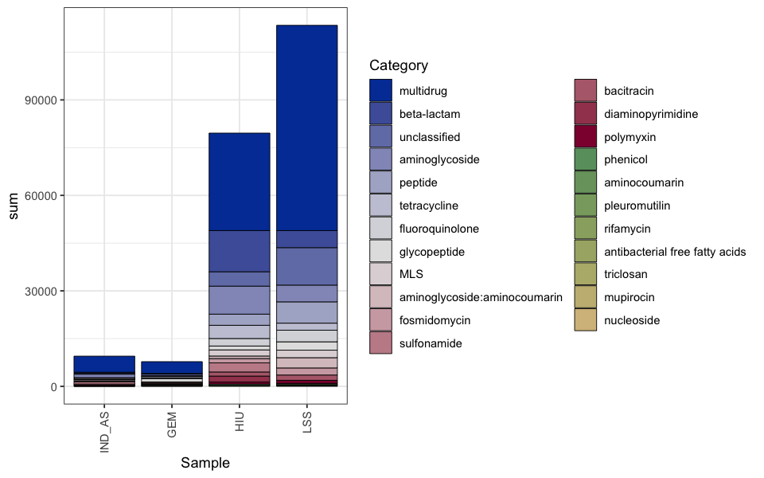

```r
ggplot(data)+geom_bar(aes(Sample, y=sum, fill=Category ), colour="black", stat='identity', size=0.25)+theme_bw() +
scale_fill_manual(
    values = c(
        diverge_hcl(15, h=c(260,0)),
        terrain_hcl(15, c=c(40, 80)),
        heat_hcl(7)
    )
) +
theme(axis.text.x = element_text(angle=90, hjust=1, vjust=0.5))
```

## Remarks

To process any other category such as MGEs, MRGs, etc. modify this line accordingly to the Section you want to analyze:

`args = x[x$Section==1,]`